# The CEP Economist Twizz

Welcome to the CEP Economist Twizz!

Do you know which words your colleagues are made of?

To play, note down your best guess about which word cloud belongs to whom.

# Wordcloud Number 1

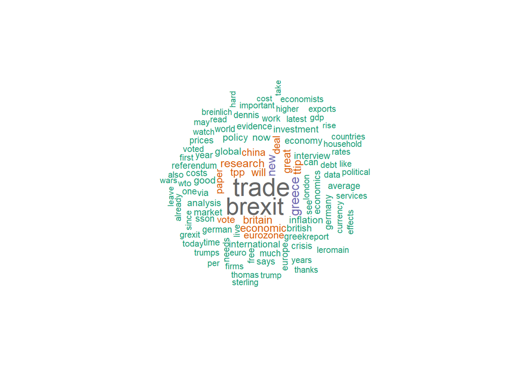

Whose wordcloud is this? Your options are:  
Paul Krugman | Paul Romer | John Van Reenen | Stiglitz | Dani Rodrik | Piketty | Lawrence Summers | Steve Machin | Henry Overman | Daron Acemoglu | David Autor | Raffaella Sadun | Sandra McNally | Matthew Kahn | Max Nathan | Thomas Sampson | Swati | Gianmario Impullitti | Romesh | Dennis Novy | Richard Davies | Rebecca Henderson | Oriana Bandiera | Anna Valero | Emily Oster |

# Wordcloud Number 2

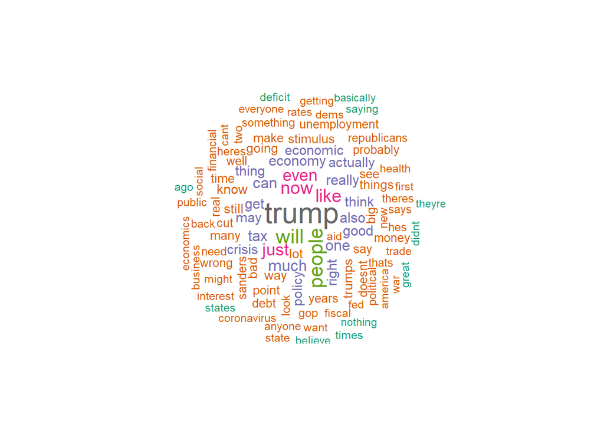

Whose wordcloud is this? Your options are:  
Paul Krugman | Paul Romer | John Van Reenen | Stiglitz | Dani Rodrik | Piketty | Lawrence Summers | Steve Machin | Henry Overman | Daron Acemoglu | David Autor | Raffaella Sadun | Sandra McNally | Matthew Kahn | Max Nathan | Thomas Sampson | Swati | Gianmario Impullitti | Romesh | Dennis Novy | Richard Davies | Rebecca Henderson | Oriana Bandiera | Anna Valero | Emily Oster |

# Wordcloud Number 3

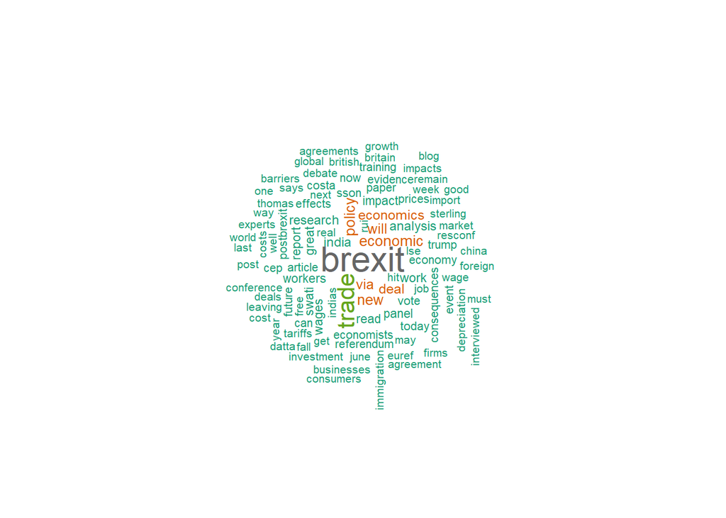

Whose wordcloud is this? Your options are:  
Paul Krugman | Paul Romer | John Van Reenen | Stiglitz | Dani Rodrik | Piketty | Lawrence Summers | Steve Machin | Henry Overman | Daron Acemoglu | David Autor | Raffaella Sadun | Sandra McNally | Matthew Kahn | Max Nathan | Thomas Sampson | Swati | Gianmario Impullitti | Romesh | Dennis Novy | Richard Davies | Rebecca Henderson | Oriana Bandiera | Anna Valero | Emily Oster |

# Wordcloud Number 4

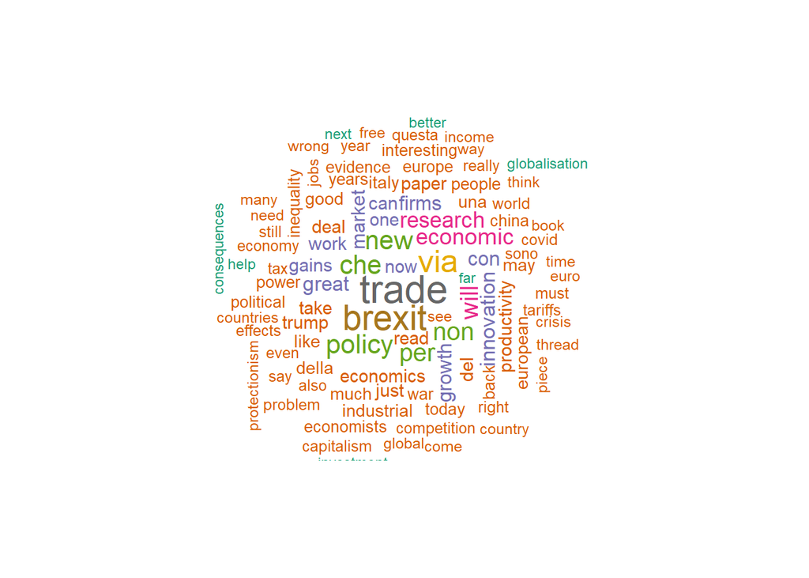

Whose wordcloud is this? Your options are:  
Paul Krugman | Paul Romer | John Van Reenen | Stiglitz | Dani Rodrik | Piketty | Lawrence Summers | Steve Machin | Henry Overman | Daron Acemoglu | David Autor | Raffaella Sadun | Sandra McNally | Matthew Kahn | Max Nathan | Thomas Sampson | Swati | Gianmario Impullitti | Romesh | Dennis Novy | Richard Davies | Rebecca Henderson | Oriana Bandiera | Anna Valero | Emily Oster |

# Wordcloud Number 5

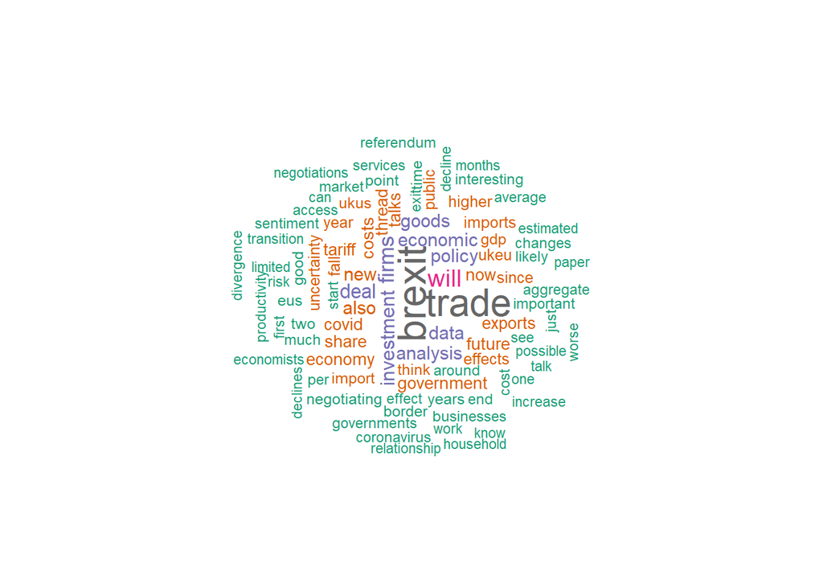

Whose wordcloud is this? Your options are:  
Paul Krugman | Paul Romer | John Van Reenen | Stiglitz | Dani Rodrik | Piketty | Lawrence Summers | Steve Machin | Henry Overman | Daron Acemoglu | David Autor | Raffaella Sadun | Sandra McNally | Matthew Kahn | Max Nathan | Thomas Sampson | Swati | Gianmario Impullitti | Romesh | Dennis Novy | Richard Davies | Rebecca Henderson | Oriana Bandiera | Anna Valero | Emily Oster |

# Wordcloud Number 6

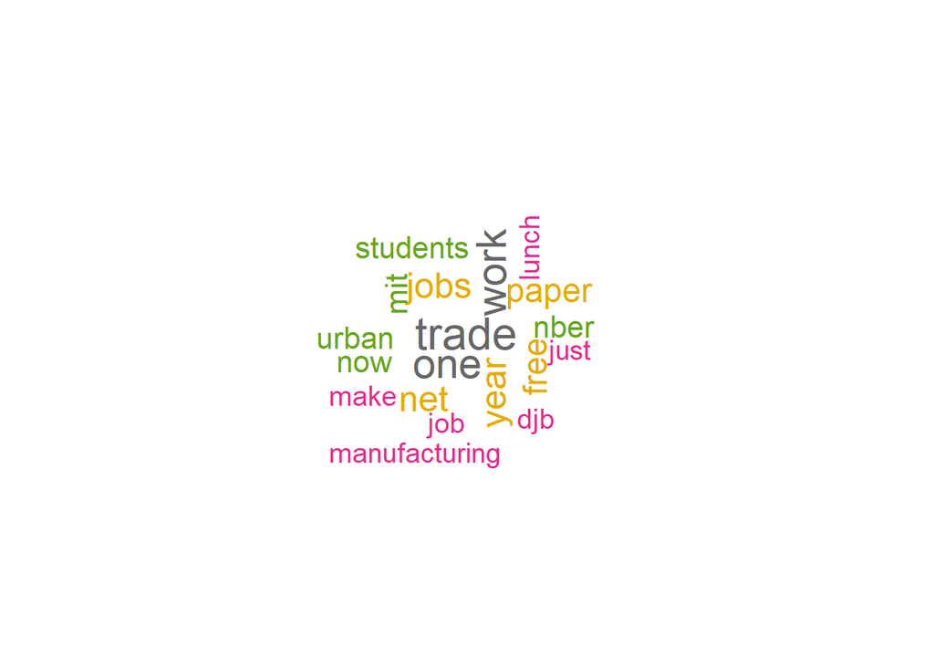

Whose wordcloud is this? Your options are:  
Paul Krugman | Paul Romer | John Van Reenen | Stiglitz | Dani Rodrik | Piketty | Lawrence Summers | Steve Machin | Henry Overman | Daron Acemoglu | David Autor | Raffaella Sadun | Sandra McNally | Matthew Kahn | Max Nathan | Thomas Sampson | Swati | Gianmario Impullitti | Romesh | Dennis Novy | Richard Davies | Rebecca Henderson | Oriana Bandiera | Anna Valero | Emily Oster |

# Wordcloud Number 7

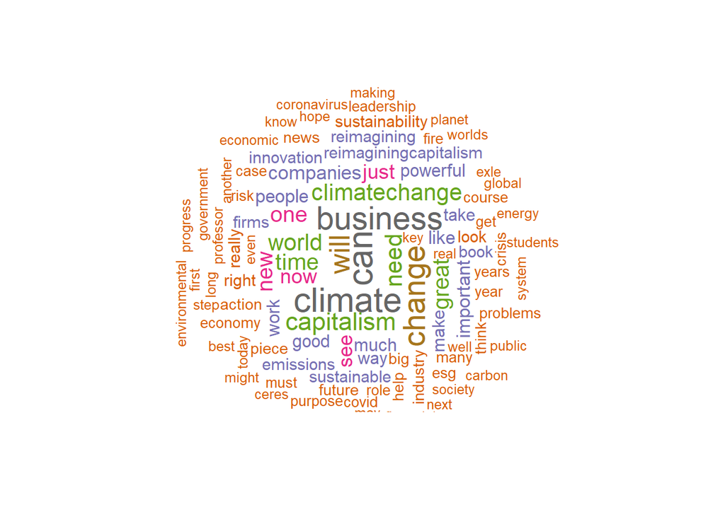

Whose wordcloud is this? Your options are:  
Paul Krugman | Paul Romer | John Van Reenen | Stiglitz | Dani Rodrik | Piketty | Lawrence Summers | Steve Machin | Henry Overman | Daron Acemoglu | David Autor | Raffaella Sadun | Sandra McNally | Matthew Kahn | Max Nathan | Thomas Sampson | Swati | Gianmario Impullitti | Romesh | Dennis Novy | Richard Davies | Rebecca Henderson | Oriana Bandiera | Anna Valero | Emily Oster |

# Wordcloud Number 8

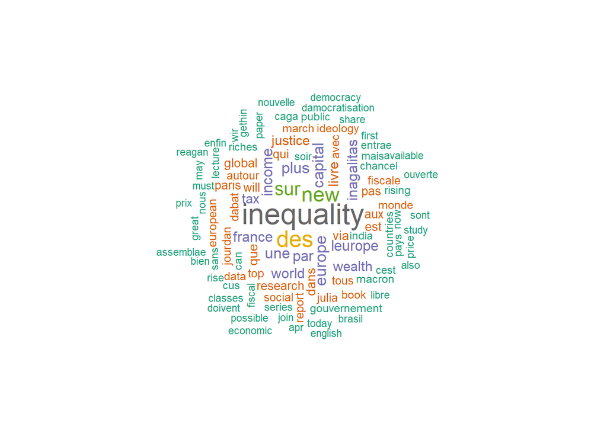

Whose wordcloud is this? Your options are:  
Paul Krugman | Paul Romer | John Van Reenen | Stiglitz | Dani Rodrik | Piketty | Lawrence Summers | Steve Machin | Henry Overman | Daron Acemoglu | David Autor | Raffaella Sadun | Sandra McNally | Matthew Kahn | Max Nathan | Thomas Sampson | Swati | Gianmario Impullitti | Romesh | Dennis Novy | Richard Davies | Rebecca Henderson | Oriana Bandiera | Anna Valero | Emily Oster |

# Wordcloud Number 9

[figure not shown]

Whose wordcloud is this? Your options are:  
Paul Krugman | Paul Romer | John Van Reenen | Stiglitz | Dani Rodrik | Piketty | Lawrence Summers | Steve Machin | Henry Overman | Daron Acemoglu | David Autor | Raffaella Sadun | Sandra McNally | Matthew Kahn | Max Nathan | Thomas Sampson | Swati | Gianmario Impullitti | Romesh | Dennis Novy | Richard Davies | Rebecca Henderson | Oriana Bandiera | Anna Valero | Emily Oster |

# Wordcloud Number 10

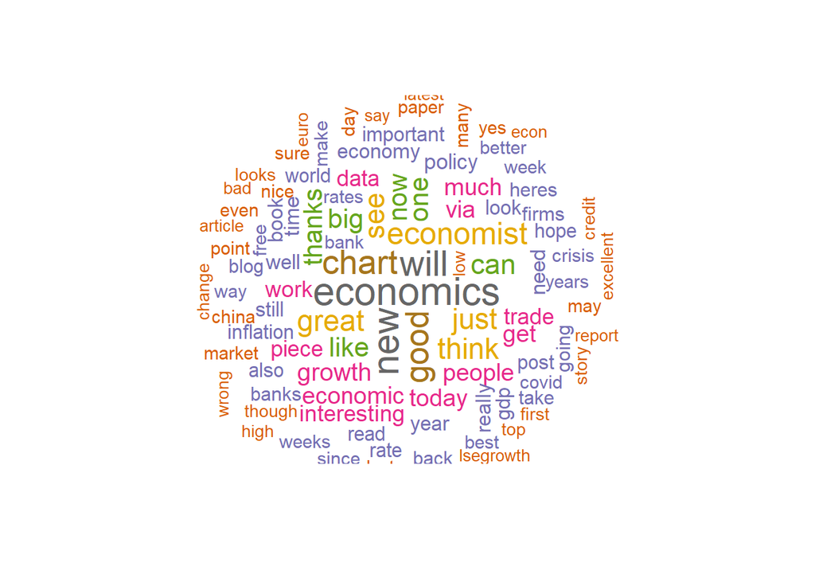

Whose wordcloud is this? Your options are:  
Paul Krugman | Paul Romer | John Van Reenen | Stiglitz | Dani Rodrik | Piketty | Lawrence Summers | Steve Machin | Henry Overman | Daron Acemoglu | David Autor | Raffaella Sadun | Sandra McNally | Matthew Kahn | Max Nathan | Thomas Sampson | Swati | Gianmario Impullitti | Romesh | Dennis Novy | Richard Davies | Rebecca Henderson | Oriana Bandiera | Anna Valero | Emily Oster |

# Wordcloud Number 11

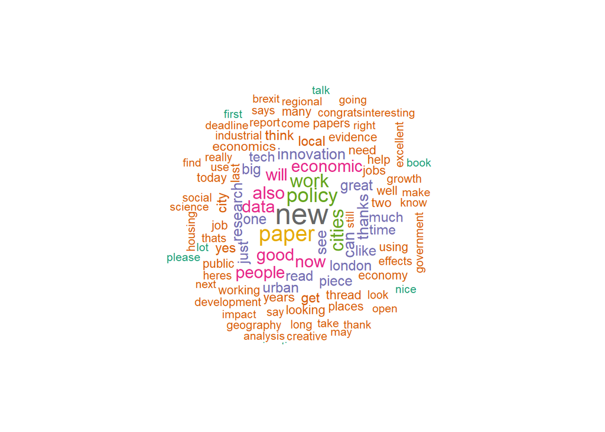

Whose wordcloud is this? Your options are:  
Paul Krugman | Paul Romer | John Van Reenen | Stiglitz | Dani Rodrik | Piketty | Lawrence Summers | Steve Machin | Henry Overman | Daron Acemoglu | David Autor | Raffaella Sadun | Sandra McNally | Matthew Kahn | Max Nathan | Thomas Sampson | Swati | Gianmario Impullitti | Romesh | Dennis Novy | Richard Davies | Rebecca Henderson | Oriana Bandiera | Anna Valero | Emily Oster |

# Wordcloud Number 12

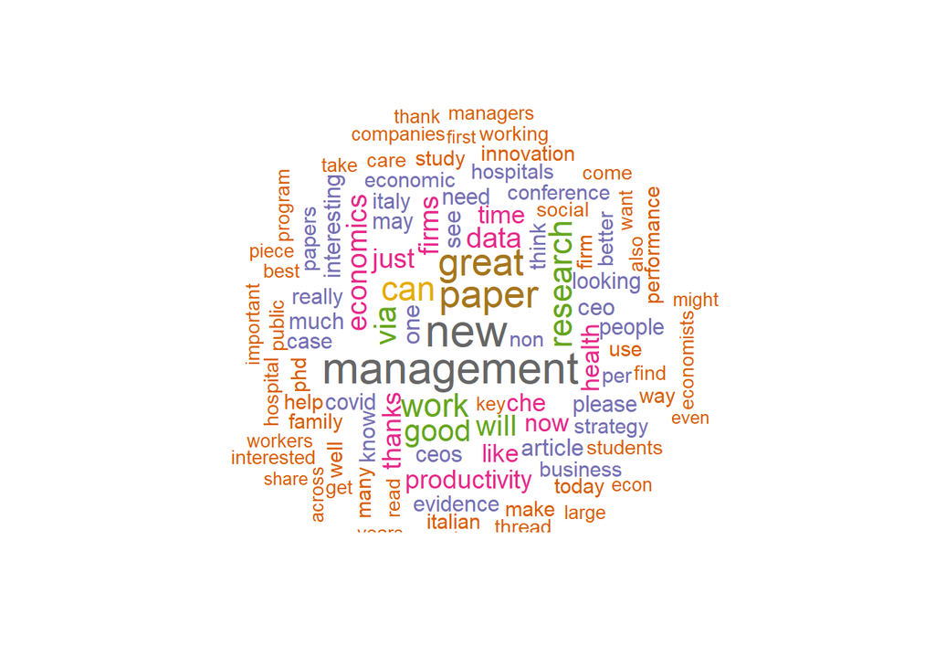

Whose wordcloud is this? Your options are:  
Paul Krugman | Paul Romer | John Van Reenen | Stiglitz | Dani Rodrik | Piketty | Lawrence Summers | Steve Machin | Henry Overman | Daron Acemoglu | David Autor | Raffaella Sadun | Sandra McNally | Matthew Kahn | Max Nathan | Thomas Sampson | Swati | Gianmario Impullitti | Romesh | Dennis Novy | Richard Davies | Rebecca Henderson | Oriana Bandiera | Anna Valero | Emily Oster |

# Wordcloud Number 13

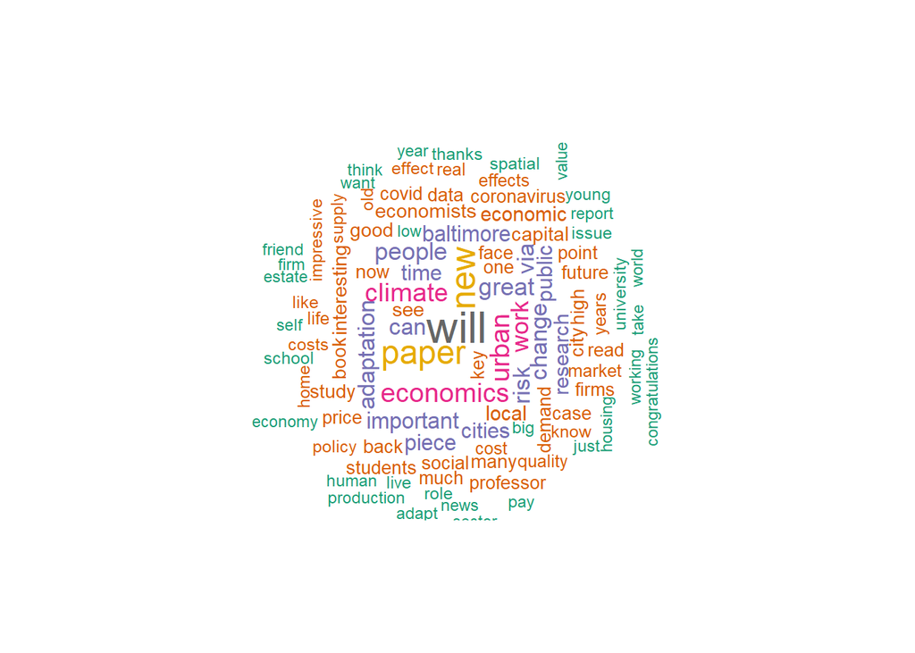

Whose wordcloud is this? Your options are:  
Paul Krugman | Paul Romer | John Van Reenen | Stiglitz | Dani Rodrik | Piketty | Lawrence Summers | Steve Machin | Henry Overman | Daron Acemoglu | David Autor | Raffaella Sadun | Sandra McNally | Matthew Kahn | Max Nathan | Thomas Sampson | Swati | Gianmario Impullitti | Romesh | Dennis Novy | Richard Davies | Rebecca Henderson | Oriana Bandiera | Anna Valero | Emily Oster |

# Wordcloud Number 14

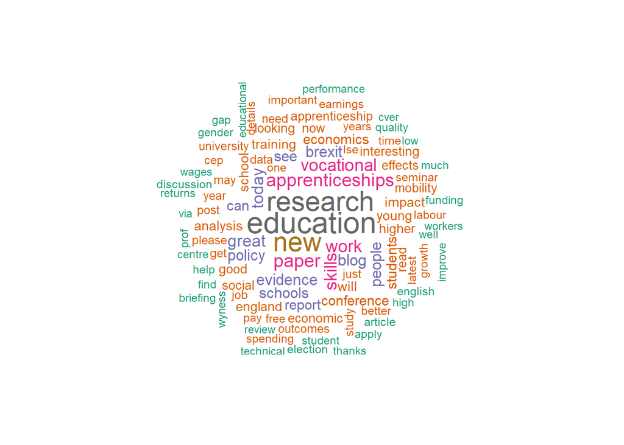

Whose wordcloud is this? Your options are:  
Paul Krugman | Paul Romer | John Van Reenen | Stiglitz | Dani Rodrik | Piketty | Lawrence Summers | Steve Machin | Henry Overman | Daron Acemoglu | David Autor | Raffaella Sadun | Sandra McNally | Matthew Kahn | Max Nathan | Thomas Sampson | Swati | Gianmario Impullitti | Romesh | Dennis Novy | Richard Davies | Rebecca Henderson | Oriana Bandiera | Anna Valero | Emily Oster |

# Wordcloud Number 15

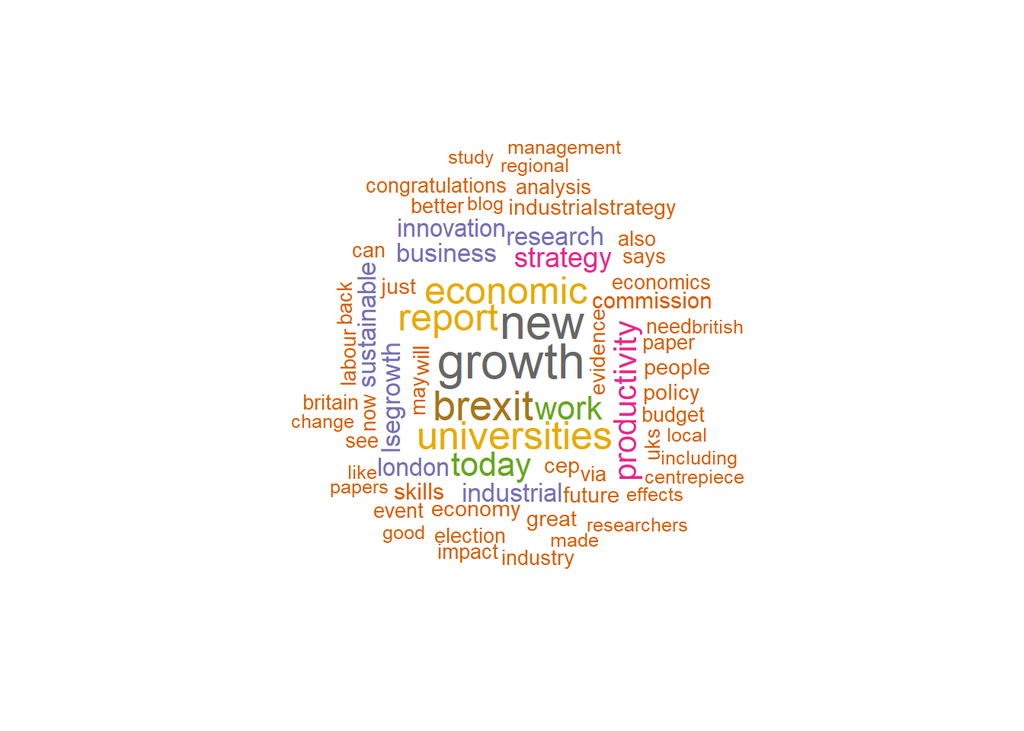

Whose wordcloud is this? Your options are:  
Paul Krugman | Paul Romer | John Van Reenen | Stiglitz | Dani Rodrik | Piketty | Lawrence Summers | Steve Machin | Henry Overman | Daron Acemoglu | David Autor | Raffaella Sadun | Sandra McNally | Matthew Kahn | Max Nathan | Thomas Sampson | Swati | Gianmario Impullitti | Romesh | Dennis Novy | Richard Davies | Rebecca Henderson | Oriana Bandiera | Anna Valero | Emily Oster |

# Wordcloud Number 16

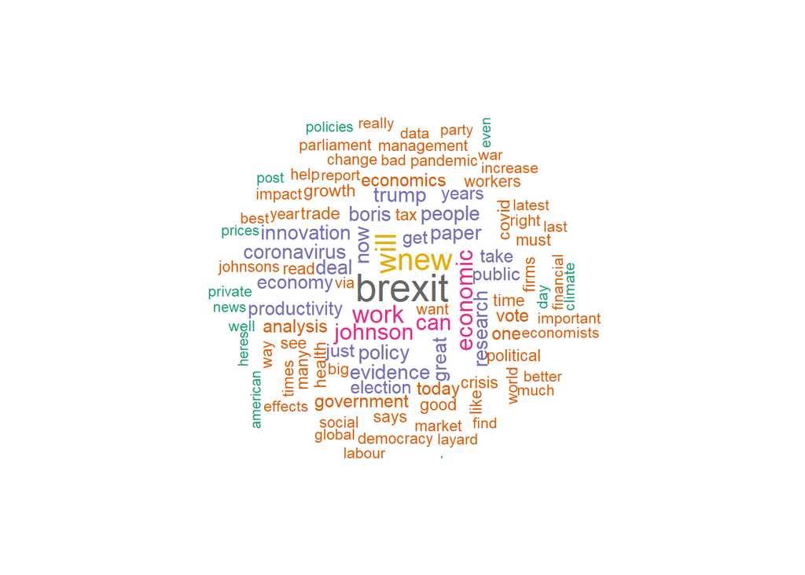

Whose wordcloud is this? Your options are:  
Paul Krugman | Paul Romer | John Van Reenen | Stiglitz | Dani Rodrik | Piketty | Lawrence Summers | Steve Machin | Henry Overman | Daron Acemoglu | David Autor | Raffaella Sadun | Sandra McNally | Matthew Kahn | Max Nathan | Thomas Sampson | Swati | Gianmario Impullitti | Romesh | Dennis Novy | Richard Davies | Rebecca Henderson | Oriana Bandiera | Anna Valero | Emily Oster |

# Wordcloud Number 17

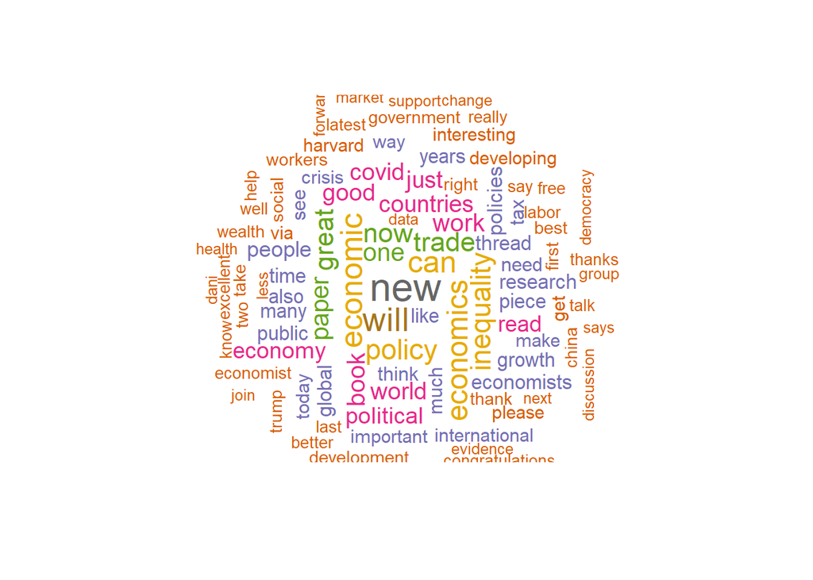

Whose wordcloud is this? Your options are:  
Paul Krugman | Paul Romer | John Van Reenen | Stiglitz | Dani Rodrik | Piketty | Lawrence Summers | Steve Machin | Henry Overman | Daron Acemoglu | David Autor | Raffaella Sadun | Sandra McNally | Matthew Kahn | Max Nathan | Thomas Sampson | Swati | Gianmario Impullitti | Romesh | Dennis Novy | Richard Davies | Rebecca Henderson | Oriana Bandiera | Anna Valero | Emily Oster |

# Wordcloud Number 18

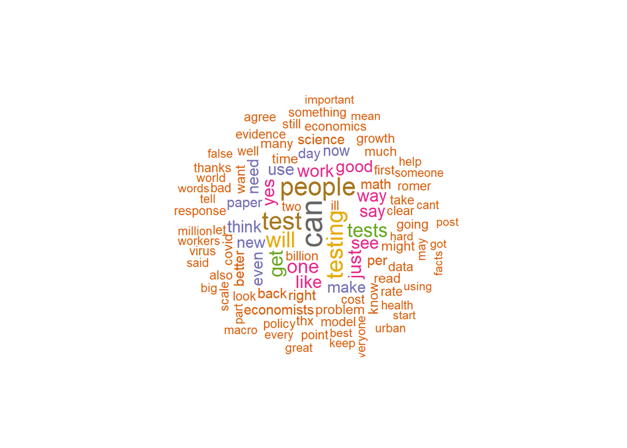

Whose wordcloud is this? Your options are:  
Paul Krugman | Paul Romer | John Van Reenen | Stiglitz | Dani Rodrik | Piketty | Lawrence Summers | Steve Machin | Henry Overman | Daron Acemoglu | David Autor | Raffaella Sadun | Sandra McNally | Matthew Kahn | Max Nathan | Thomas Sampson | Swati | Gianmario Impullitti | Romesh | Dennis Novy | Richard Davies | Rebecca Henderson | Oriana Bandiera | Anna Valero | Emily Oster |

# Wordcloud Number 19

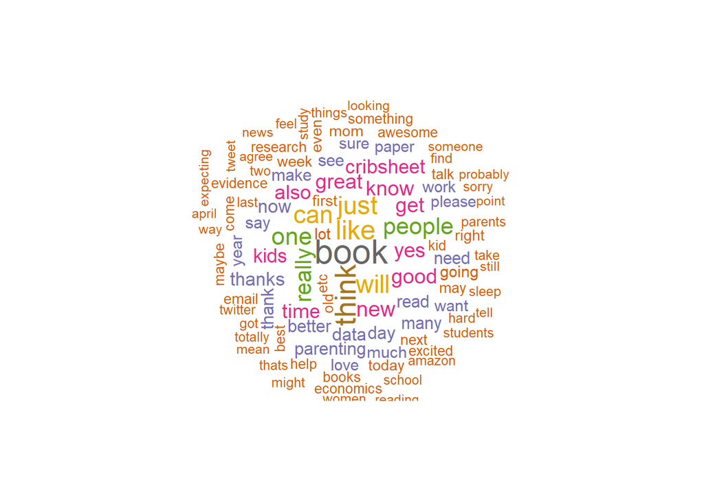

Whose wordcloud is this? Your options are:  
Paul Krugman | Paul Romer | John Van Reenen | Stiglitz | Dani Rodrik | Piketty | Lawrence Summers | Steve Machin | Henry Overman | Daron Acemoglu | David Autor | Raffaella Sadun | Sandra McNally | Matthew Kahn | Max Nathan | Thomas Sampson | Swati | Gianmario Impullitti | Romesh | Dennis Novy | Richard Davies | Rebecca Henderson | Oriana Bandiera | Anna Valero | Emily Oster |

# Wordcloud Number 20

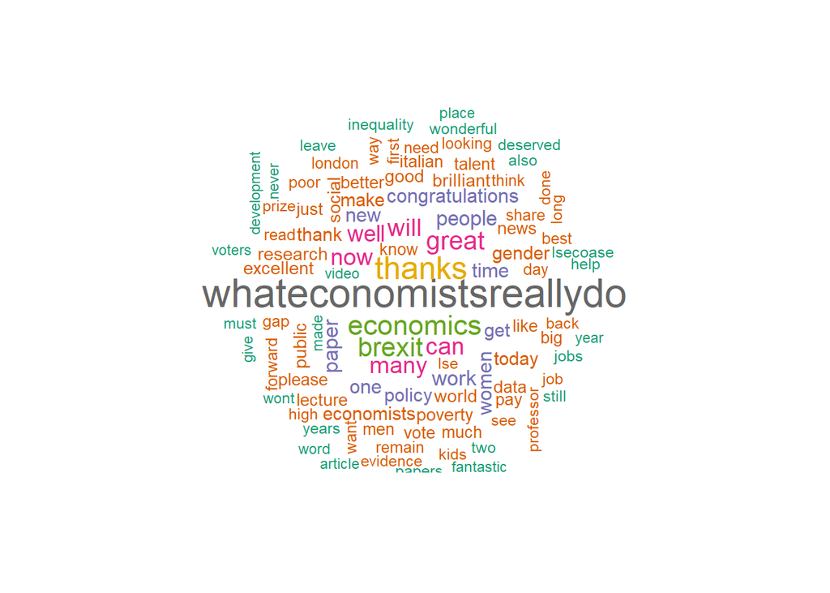

Whose wordcloud is this? Your options are:  
Paul Krugman | Paul Romer | John Van Reenen | Stiglitz | Dani Rodrik | Piketty | Lawrence Summers | Steve Machin | Henry Overman | Daron Acemoglu | David Autor | Raffaella Sadun | Sandra McNally | Matthew Kahn | Max Nathan | Thomas Sampson | Swati | Gianmario Impullitti | Romesh | Dennis Novy | Richard Davies | Rebecca Henderson | Oriana Bandiera | Anna Valero | Emily Oster |

# Wordcloud Number 21

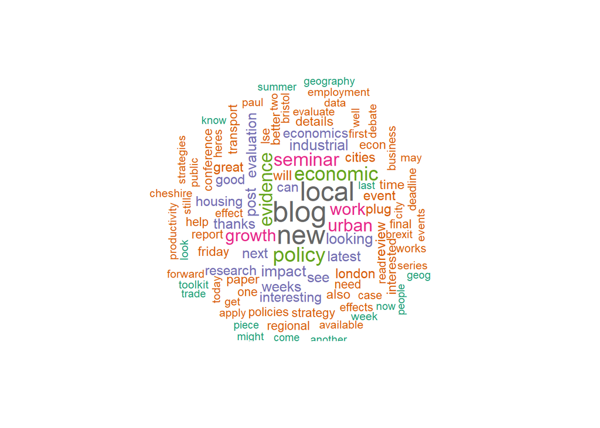

Whose wordcloud is this? Your options are:  
Paul Krugman | Paul Romer | John Van Reenen | Stiglitz | Dani Rodrik | Piketty | Lawrence Summers | Steve Machin | Henry Overman | Daron Acemoglu | David Autor | Raffaella Sadun | Sandra McNally | Matthew Kahn | Max Nathan | Thomas Sampson | Swati | Gianmario Impullitti | Romesh | Dennis Novy | Richard Davies | Rebecca Henderson | Oriana Bandiera | Anna Valero | Emily Oster |

# Wordcloud Number 22

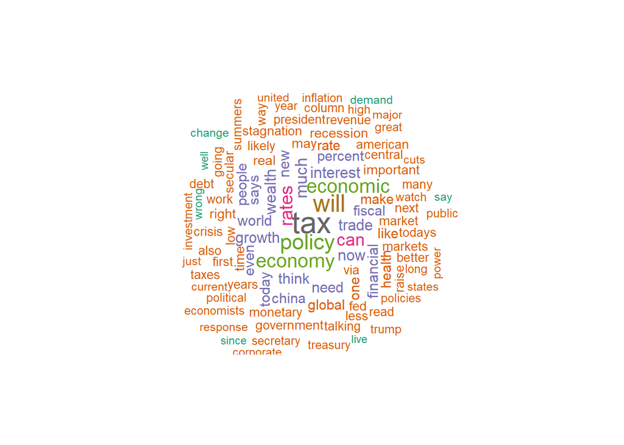

Whose wordcloud is this? Your options are:  
Paul Krugman | Paul Romer | John Van Reenen | Stiglitz | Dani Rodrik | Piketty | Lawrence Summers | Steve Machin | Henry Overman | Daron Acemoglu | David Autor | Raffaella Sadun | Sandra McNally | Matthew Kahn | Max Nathan | Thomas Sampson | Swati | Gianmario Impullitti | Romesh | Dennis Novy | Richard Davies | Rebecca Henderson | Oriana Bandiera | Anna Valero | Emily Oster |

# Wordcloud Number 23

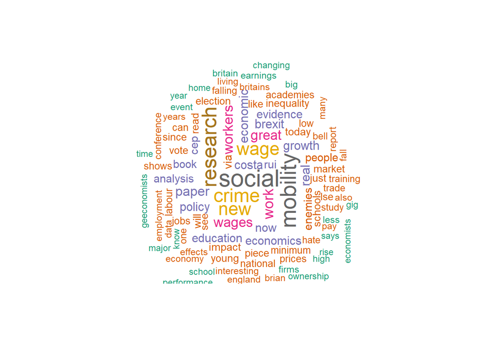

Whose wordcloud is this? Your options are:  
Paul Krugman | Paul Romer | John Van Reenen | Stiglitz | Dani Rodrik | Piketty | Lawrence Summers | Steve Machin | Henry Overman | Daron Acemoglu | David Autor | Raffaella Sadun | Sandra McNally | Matthew Kahn | Max Nathan | Thomas Sampson | Swati | Gianmario Impullitti | Romesh | Dennis Novy | Richard Davies | Rebecca Henderson | Oriana Bandiera | Anna Valero | Emily Oster |

# Wordcloud Number 24

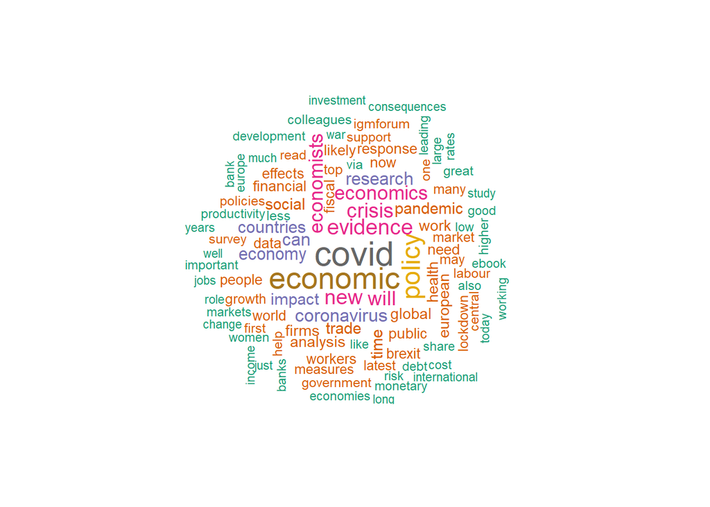

Whose wordcloud is this? Your options are:  
Paul Krugman | Paul Romer | John Van Reenen | Stiglitz | Dani Rodrik | Piketty | Lawrence Summers | Steve Machin | Henry Overman | Daron Acemoglu | David Autor | Raffaella Sadun | Sandra McNally | Matthew Kahn | Max Nathan | Thomas Sampson | Swati | Gianmario Impullitti | Romesh | Dennis Novy | Richard Davies | Rebecca Henderson | Oriana Bandiera | Anna Valero | Emily Oster |

# Wordcloud Number 25

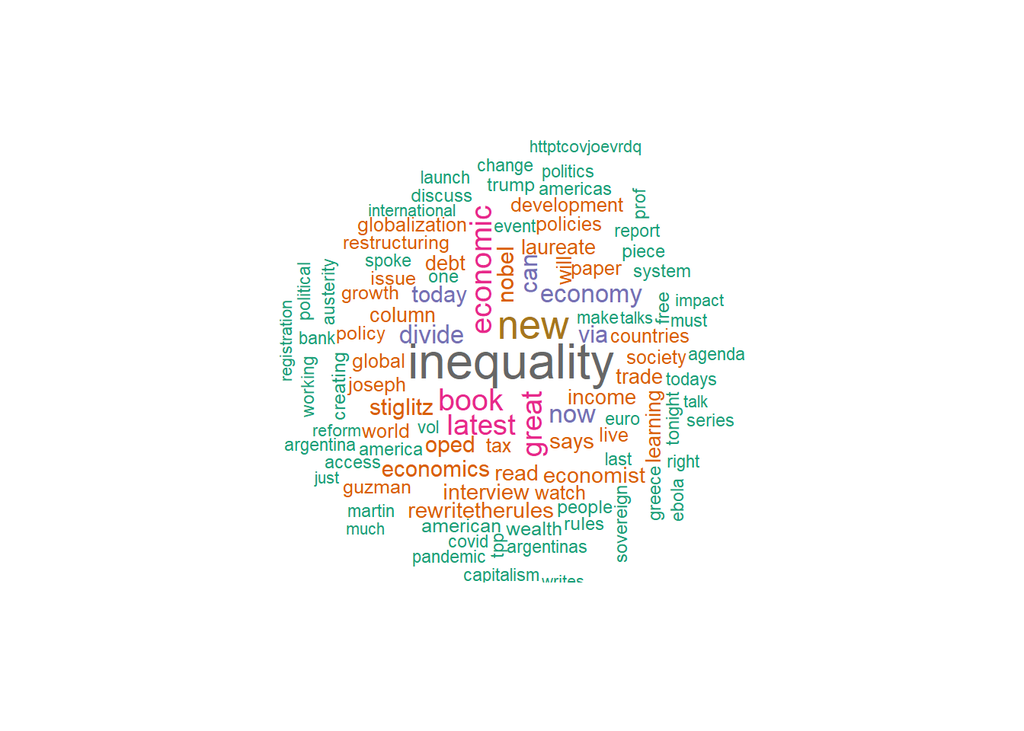

Whose wordcloud is this? Your options are:  
Paul Krugman | Paul Romer | John Van Reenen | Stiglitz | Dani Rodrik | Piketty | Lawrence Summers | Steve Machin | Henry Overman | Daron Acemoglu | David Autor | Raffaella Sadun | Sandra McNally | Matthew Kahn | Max Nathan | Thomas Sampson | Swati | Gianmario Impullitti | Romesh | Dennis Novy | Richard Davies | Rebecca Henderson | Oriana Bandiera | Anna Valero | Emily Oster |